# Analysis Heart Disease using Logistic Regression and K-Nearest Neighbors

Gasha Sarwono

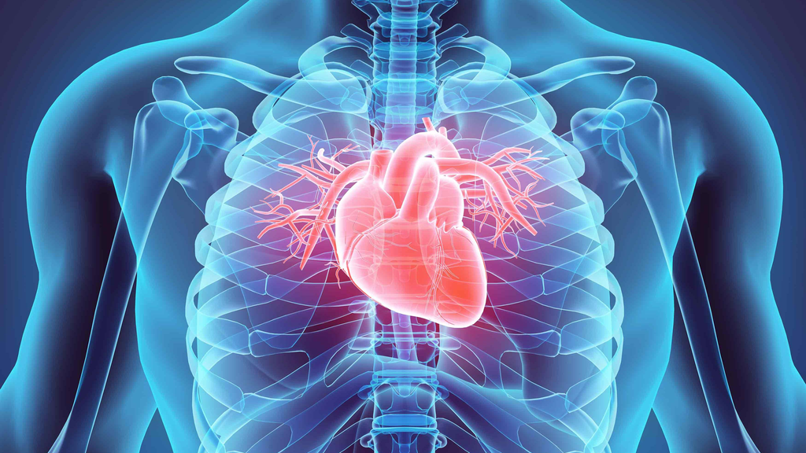

### 1. Background

#### - target : (Heart Disease / Not Heart Disease)

#### For dataset I get from kaggle in this link:

#### https://www.kaggle.com/ronitf/heart-disease-uci

### 2. Set Up

**Activated Library**

```r
library(dplyr) #make plot
library(tidyverse) #wrangling data
library(rsample) #sampling data
library(car) #check vif
library(caret) #confussion matrix
library(lmtest) #cek asumsi
library(class) #knn predict

options(scipen = 999)
```

**Import Data**

```r
heart <- read.csv("heart.csv")
heart
```

| ï..age | sex | cp | trestbps | chol | fbs | restecg | thalach | exang | oldpeak | slope | ca | thal | target |
| --- | --- | --- | --- | --- | --- | --- | --- | --- | --- | --- | --- | --- | --- |
| 63 | 1 | 3 | 145 | 233 | 1 | 0 | 150 | 0 | 2.3 | 0 | 0 | 1 | 1 |
| 37 | 1 | 2 | 130 | 250 | 0 | 1 | 187 | 0 | 3.5 | 0 | 0 | 2 | 1 |
| 41 | 0 | 1 | 130 | 204 | 0 | 0 | 172 | 0 | 1.4 | 2 | 0 | 2 | 1 |
| 56 | 1 | 1 | 120 | 236 | 0 | 1 | 178 | 0 | 0.8 | 2 | 0 | 2 | 1 |
| 57 | 0 | 0 | 120 | 354 | 0 | 1 | 163 | 1 | 0.6 | 2 | 0 | 2 | 1 |
| 57 | 1 | 0 | 140 | 192 | 0 | 1 | 148 | 0 | 0.4 | 1 | 0 | 1 | 1 |
| 56 | 0 | 1 | 140 | 294 | 0 | 0 | 153 | 0 | 1.3 | 1 | 0 | 2 | 1 |
| 44 | 1 | 1 | 120 | 263 | 0 | 1 | 173 | 0 | 0.0 | 2 | 0 | 3 | 1 |
| 52 | 1 | 2 | 172 | 199 | 1 | 1 | 162 | 0 | 0.5 | 2 | 0 | 3 | 1 |
| 57 | 1 | 2 | 150 | 168 | 0 | 1 | 174 | 0 | 1.6 | 2 | 0 | 2 | 1 |

[output cut: 293 more lines]

### 3. Data Inspection

**Check Data Type**

```r
glimpse(heart)
```

```
## Rows: 303
## Columns: 14
## $ ï..age   <int> 63, 37, 41, 56, 57, 57, 56, 44, 52, 57, 54, 48, 49, 64, 58...
## $ sex      <int> 1, 1, 0, 1, 0, 1, 0, 1, 1, 1, 1, 0, 1, 1, 0, 0, 0, 0, 1, 0...
## $ cp       <int> 3, 2, 1, 1, 0, 0, 1, 1, 2, 2, 0, 2, 1, 3, 3, 2, 2, 3, 0, 3...
## $ trestbps <int> 145, 130, 130, 120, 120, 140, 140, 120, 172, 150, 140, 130...
## $ chol     <int> 233, 250, 204, 236, 354, 192, 294, 263, 199, 168, 239, 275...
## $ fbs      <int> 1, 0, 0, 0, 0, 0, 0, 0, 1, 0, 0, 0, 0, 0, 1, 0, 0, 0, 0, 0...
## $ restecg  <int> 0, 1, 0, 1, 1, 1, 0, 1, 1, 1, 1, 1, 1, 0, 0, 1, 1, 1, 1, 1...
## $ thalach  <int> 150, 187, 172, 178, 163, 148, 153, 173, 162, 174, 160, 139...
## $ exang    <int> 0, 0, 0, 0, 1, 0, 0, 0, 0, 0, 0, 0, 0, 1, 0, 0, 0, 0, 0, 0...
## $ oldpeak  <dbl> 2.3, 3.5, 1.4, 0.8, 0.6, 0.4, 1.3, 0.0, 0.5, 1.6, 1.2, 0.2...
## $ slope    <int> 0, 0, 2, 2, 2, 1, 1, 2, 2, 2, 2, 2, 2, 1, 2, 1, 2, 0, 2, 2...
## $ ca       <int> 0, 0, 0, 0, 0, 0, 0, 0, 0, 0, 0, 0, 0, 0, 0, 0, 0, 0, 0, 2...
## $ thal     <int> 1, 2, 2, 2, 2, 1, 2, 3, 3, 2, 2, 2, 2, 2, 2, 2, 2, 2, 2, 2...
## $ target   <int> 1, 1, 1, 1, 1, 1, 1, 1, 1, 1, 1, 1, 1, 1, 1, 1, 1, 1, 1, 1...
```

For variabel sex, cp, fbs, restecg, exang, slope, ca, thal, and target must change with factor data type

**Change Data Type**

```r
#Change data type
heart <-
  heart %>%
  mutate_at(vars(sex,cp,fbs,restecg,exang,slope,ca,thal,target),funs(as.factor))

#Check data type after change
glimpse(heart)
```

```
## Rows: 303
## Columns: 14
## $ ï..age   <int> 63, 37, 41, 56, 57, 57, 56, 44, 52, 57, 54, 48, 49, 64, 58...
## $ sex      <fct> 1, 1, 0, 1, 0, 1, 0, 1, 1, 1, 1, 0, 1, 1, 0, 0, 0, 0, 1, 0...
## $ cp       <fct> 3, 2, 1, 1, 0, 0, 1, 1, 2, 2, 0, 2, 1, 3, 3, 2, 2, 3, 0, 3...
## $ trestbps <int> 145, 130, 130, 120, 120, 140, 140, 120, 172, 150, 140, 130...
## $ chol     <int> 233, 250, 204, 236, 354, 192, 294, 263, 199, 168, 239, 275...
## $ fbs      <fct> 1, 0, 0, 0, 0, 0, 0, 0, 1, 0, 0, 0, 0, 0, 1, 0, 0, 0, 0, 0...
## $ restecg  <fct> 0, 1, 0, 1, 1, 1, 0, 1, 1, 1, 1, 1, 1, 0, 0, 1, 1, 1, 1, 1...
## $ thalach  <int> 150, 187, 172, 178, 163, 148, 153, 173, 162, 174, 160, 139...
## $ exang    <fct> 0, 0, 0, 0, 1, 0, 0, 0, 0, 0, 0, 0, 0, 1, 0, 0, 0, 0, 0, 0...
## $ oldpeak  <dbl> 2.3, 3.5, 1.4, 0.8, 0.6, 0.4, 1.3, 0.0, 0.5, 1.6, 1.2, 0.2...
## $ slope    <fct> 0, 0, 2, 2, 2, 1, 1, 2, 2, 2, 2, 2, 2, 1, 2, 1, 2, 0, 2, 2...
## $ ca       <fct> 0, 0, 0, 0, 0, 0, 0, 0, 0, 0, 0, 0, 0, 0, 0, 0, 0, 0, 0, 2...
## $ thal     <fct> 1, 2, 2, 2, 2, 1, 2, 3, 3, 2, 2, 2, 2, 2, 2, 2, 2, 2, 2, 2...
## $ target   <fct> 1, 1, 1, 1, 1, 1, 1, 1, 1, 1, 1, 1, 1, 1, 1, 1, 1, 1, 1, 1...
```

**Check Missing Value**

```r
colSums(is.na(heart))
```

```
##   ï..age      sex       cp trestbps     chol      fbs  restecg  thalach
##        0        0        0        0        0        0        0        0
##    exang  oldpeak    slope       ca     thal   target
##        0        0        0        0        0        0
```

All variabel no have missing data.

**Change Description Data**

```r
heart <-
  heart %>%
   mutate(sex = factor(sex, levels = c(0,1), labels = c("Female", "Male")),
         fbs =factor(fbs, levels = c(0,1), labels = c("False", "True")),
         exang = factor(exang, levels = c(0,1), labels = c("No", "Yes")),
         target = factor(target, levels = c(0,1), labels = c("Not Heart Disease", "Heart Disease")))
heart
```

| ï..age | sex | cp | trestbps | chol | fbs | restecg | thalach | exang | oldpeak | slope | ca | thal | target |
| --- | --- | --- | --- | --- | --- | --- | --- | --- | --- | --- | --- | --- | --- |
| 63 | Male | 3 | 145 | 233 | True | 0 | 150 | No | 2.3 | 0 | 0 | 1 | Heart Disease |
| 37 | Male | 2 | 130 | 250 | False | 1 | 187 | No | 3.5 | 0 | 0 | 2 | Heart Disease |
| 41 | Female | 1 | 130 | 204 | False | 0 | 172 | No | 1.4 | 2 | 0 | 2 | Heart Disease |
| 56 | Male | 1 | 120 | 236 | False | 1 | 178 | No | 0.8 | 2 | 0 | 2 | Heart Disease |
| 57 | Female | 0 | 120 | 354 | False | 1 | 163 | Yes | 0.6 | 2 | 0 | 2 | Heart Disease |
| 57 | Male | 0 | 140 | 192 | False | 1 | 148 | No | 0.4 | 1 | 0 | 1 | Heart Disease |
| 56 | Female | 1 | 140 | 294 | False | 0 | 153 | No | 1.3 | 1 | 0 | 2 | Heart Disease |
| 44 | Male | 1 | 120 | 263 | False | 1 | 173 | No | 0.0 | 2 | 0 | 3 | Heart Disease |
| 52 | Male | 2 | 172 | 199 | True | 1 | 162 | No | 0.5 | 2 | 0 | 3 | Heart Disease |
| 57 | Male | 2 | 150 | 168 | False | 1 | 174 | No | 1.6 | 2 | 0 | 2 | Heart Disease |

[output cut: 293 more lines]

**Check Data Summary**

```r
summary(heart)
```

```
##      ï..age          sex      cp         trestbps          chol
##  Min.   :29.00   Female: 96   0:143   Min.   : 94.0   Min.   :126.0
##  1st Qu.:47.50   Male  :207   1: 50   1st Qu.:120.0   1st Qu.:211.0
##  Median :55.00                2: 87   Median :130.0   Median :240.0
##  Mean   :54.37                3: 23   Mean   :131.6   Mean   :246.3
##  3rd Qu.:61.00                        3rd Qu.:140.0   3rd Qu.:274.5
##  Max.   :77.00                        Max.   :200.0   Max.   :564.0
##     fbs      restecg    thalach      exang        oldpeak     slope   ca
##  False:258   0:147   Min.   : 71.0   No :204   Min.   :0.00   0: 21   0:175
##  True : 45   1:152   1st Qu.:133.5   Yes: 99   1st Qu.:0.00   1:140   1: 65
##              2:  4   Median :153.0             Median :0.80   2:142   2: 38
##                      Mean   :149.6             Mean   :1.04           3: 20
##                      3rd Qu.:166.0             3rd Qu.:1.60           4:  5
##                      Max.   :202.0             Max.   :6.20
##  thal                  target
##  0:  2   Not Heart Disease:138
##  1: 18   Heart Disease    :165
##  2:166
##  3:117
##
##
```

Plot Data Numeric

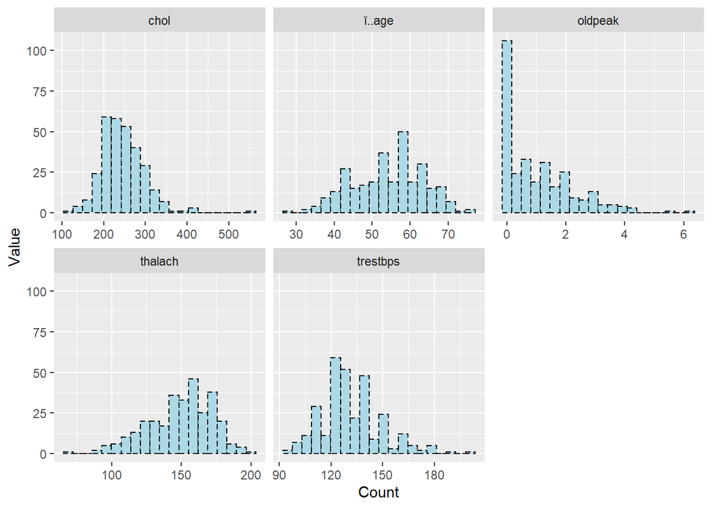

```r
ggplot(
  gather(heart %>% select_if(is.numeric)), aes(value)) +
  geom_histogram(bins = 20, color="black", fill="lightblue", linetype="dashed") +
  facet_wrap(~key, scales = 'free_x') +
  labs(x="Count", y="Value")
```

Plot Data Categoric

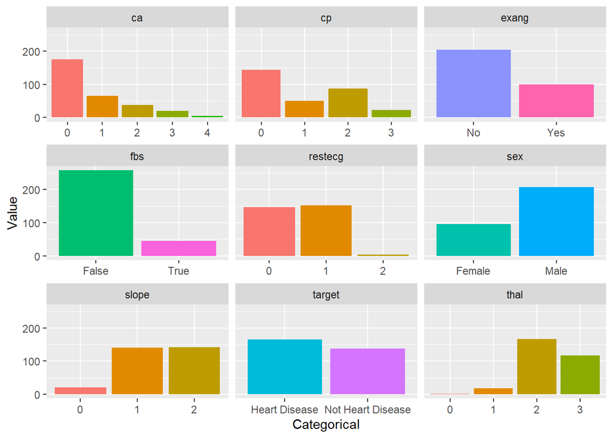

```r
ggplot(
  gather(heart %>% select_if(is.factor)), aes(value, fill=value)) +
  geom_bar(bins = 10) +
  facet_wrap(~key, scales = 'free_x') +
  theme(legend.position = "none") +
  labs(x="Categorical", y="Value")
```

Proportion Table Target Variable

```r
prop.table(table(heart$target))
```

```
##
## Not Heart Disease     Heart Disease
##         0.4554455         0.5445545
```

*Insight Data Summary:*

*-Proportion Cholesterol much on range 200-300 mg/dL*

*-Blood sugar much on less <120 mg/dL*

*-Quantity gender Male more than gender Female*

### 4. Modeling

#### 4.1 Logistic Regression

**Cross Validation**

Make data train for training model (80% proportion from actual data) and data test for testing model (20% proportion from actual data)

```r
RNGkind(sample.kind = "Rounding")
set.seed(1616)

index <- sample(nrow(heart),
                nrow(heart) *0.8)

heart_train <- heart[index, ]
heart_test <- heart[-index, ]
```

**Make model**

Make model regression with stepwise “both”

```r
modelheart <- glm(target ~ ., data = heart_train, family = "binomial")
model_log <- step(modelheart, direction = "both")
```

```
## Start:  AIC=173.27
## target ~ ï..age + sex + cp + trestbps + chol + fbs + restecg +
##     thalach + exang + oldpeak + slope + ca + thal
##
##            Df Deviance    AIC
## - restecg   2   127.99 169.99
## - oldpeak   1   128.71 172.71
## - chol      1   128.74 172.74
## - fbs       1   129.19 173.19
## <none>          127.28 173.28
## - ï..age    1   131.22 175.22
## - exang     1   131.95 175.95
## - slope     2   134.17 176.17
## - thalach   1   132.18 176.18
## - thal      3   137.33 177.33
## - cp        3   139.15 179.15
## - sex       1   135.25 179.25
## - trestbps  1   136.15 180.15
## - ca        4   175.14 213.14
##
## Step:  AIC=169.99
## target ~ ï..age + sex + cp + trestbps + chol + fbs + thalach +
##     exang + oldpeak + slope + ca + thal
##
##            Df Deviance    AIC
## - oldpeak   1   129.53 169.53
## - fbs       1   129.97 169.97
## <none>          127.99 169.99
## - chol      1   130.08 170.08
## - ï..age    1   131.81 171.81
## - exang     1   132.67 172.67
## - slope     2   134.77 172.77
## - thalach   1   132.78 172.78
## + restecg   2   127.28 173.28
## - thal      3   137.90 173.90
## - cp        3   139.54 175.54
## - sex       1   136.40 176.40
## - trestbps  1   137.01 177.01
## - ca        4   176.95 210.95
##
## Step:  AIC=169.53
## target ~ ï..age + sex + cp + trestbps + chol + fbs + thalach +
##     exang + slope + ca + thal
##
##            Df Deviance    AIC
## <none>          129.53 169.53
## - chol      1   131.71 169.71
## - fbs       1   131.82 169.82
## + oldpeak   1   127.99 169.99
## - ï..age    1   133.42 171.42
## - exang     1   134.48 172.48
## + restecg   2   128.71 172.71
## - thalach   1   134.98 172.98
## - thal      3   139.76 173.76
## - slope     2   138.16 174.16
## - cp        3   140.65 174.65
## - sex       1   138.34 176.34
## - trestbps  1   139.30 177.30
## - ca        4   181.67 213.67
```

```r
summary(model_log)
```

```
##
## Call:
## glm(formula = target ~ ï..age + sex + cp + trestbps + chol +
##     fbs + thalach + exang + slope + ca + thal, family = "binomial",
##     data = heart_train)
##
## Deviance Residuals:
##      Min        1Q    Median        3Q       Max
## -2.82624  -0.26939   0.06826   0.35126   2.51493
##
## Coefficients:
##              Estimate Std. Error z value    Pr(>|z|)
## (Intercept) -0.747449   3.835959  -0.195     0.84551
## ï..age       0.062681   0.032899   1.905     0.05675 .
## sexMale     -1.927951   0.687437  -2.805     0.00504 **
## cp1          1.188364   0.750564   1.583     0.11335
## cp2          1.676734   0.586547   2.859     0.00425 **
## cp3          1.923863   0.849410   2.265     0.02352 *
## trestbps    -0.043437   0.014820  -2.931     0.00338 **
## chol        -0.007406   0.004939  -1.500     0.13370
## fbsTrue      0.998640   0.664862   1.502     0.13309
## thalach      0.035021   0.015700   2.231     0.02570 *
## exangYes    -1.227084   0.554712  -2.212     0.02696 *
## slope1      -0.725950   0.872640  -0.832     0.40547
## slope2       0.858743   0.885462   0.970     0.33213
## ca1         -3.445803   0.703807  -4.896 0.000000978 ***
## ca2         -4.375906   0.941797  -4.646 0.000003379 ***
## ca3         -2.898257   0.988520  -2.932     0.00337 **
## ca4         -0.603644   3.552544  -0.170     0.86507
## thal1        2.807489   2.375376   1.182     0.23724
## thal2        2.336847   2.261497   1.033     0.30145
## thal3        0.967776   2.257631   0.429     0.66816
## ---
## Signif. codes:  0 '***' 0.001 '**' 0.01 '*' 0.05 '.' 0.1 ' ' 1
##
## (Dispersion parameter for binomial family taken to be 1)
##
##     Null deviance: 335.22  on 241  degrees of freedom
## Residual deviance: 129.53  on 222  degrees of freedom
## AIC: 169.53
##
## Number of Fisher Scoring iterations: 6
```

After make model and using stepwise “both” for selection prediktor variabel, optimum prediktor variabel is age, sex, cp, trestbps, chol, fbs, thalach, exang, slope, ca, thal.

**Assumption**

*Multicollinearity*

```r
vif(model_log)
```

```
##              GVIF Df GVIF^(1/(2*Df))
## ï..age   1.723208  1        1.312710
## sex      1.598750  1        1.264417
## cp       1.768155  3        1.099647
## trestbps 1.379831  1        1.174662
## chol     1.343845  1        1.159243
## fbs      1.279130  1        1.130986
## thalach  1.610393  1        1.269012
## exang    1.272209  1        1.127922
## slope    1.513998  2        1.109255
## ca       2.359953  4        1.113302
## thal     1.620655  3        1.083798
```

Value vif each variabel <10 , its mean each variabel no have correlation or same characteristic

*Linearity*

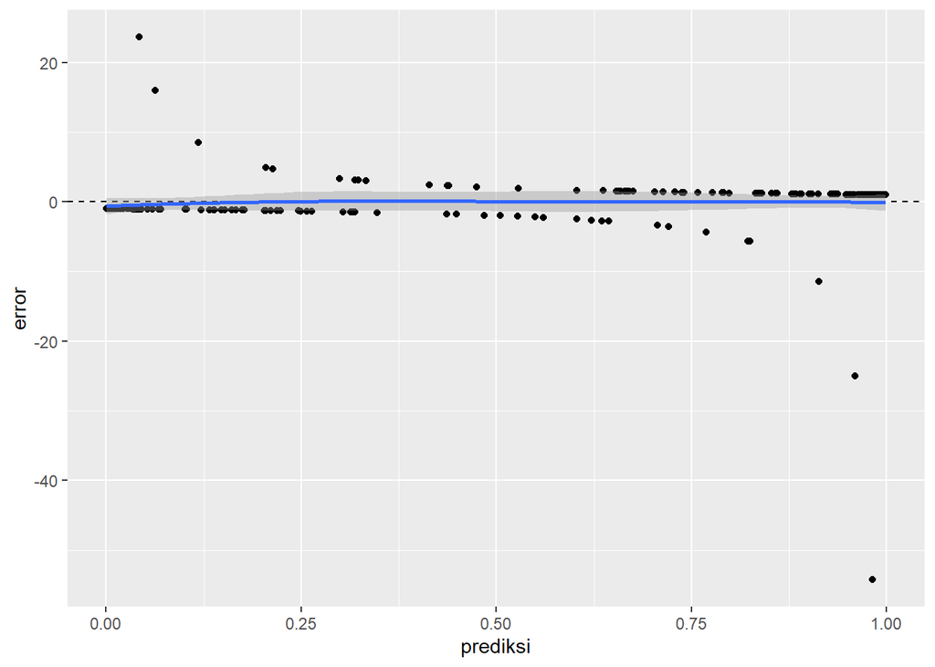

```r
data.frame(prediksi = model_log$fitted.values,
           error = model_log$residuals) %>%

  ggplot(aes(x = prediksi, y = error)) +
  geom_hline(yintercept = 0, lty = "dashed") +
  geom_point() +
  geom_smooth()
```

**Prediction**

Predict data test an save in new column

```r
heart_test$pred_result <- predict(object = model_log,
                             newdata = heart_test,
                             type = "response")
heart_test
```

|  | ï..age | sex | cp | trestbps | chol | fbs | restecg | thalach | exang | oldpeak | slope | ca | thal | target | pred_result |
| --- | --- | --- | --- | --- | --- | --- | --- | --- | --- | --- | --- | --- | --- | --- | --- |
| 7 | 56 | Female | 1 | 140 | 294 | False | 0 | 153 | No | 1.3 | 1 | 0 | 2 | Heart Disease | 0.9347203871 |
| 10 | 57 | Male | 2 | 150 | 168 | False | 1 | 174 | No | 1.6 | 2 | 0 | 2 | Heart Disease | 0.9837559174 |
| 22 | 44 | Male | 2 | 130 | 233 | False | 1 | 179 | Yes | 0.4 | 2 | 0 | 2 | Heart Disease | 0.9323983237 |
| 26 | 71 | Female | 1 | 160 | 302 | False | 1 | 162 | No | 0.4 | 2 | 2 | 2 | Heart Disease | 0.5492844090 |
| 27 | 59 | Male | 2 | 150 | 212 | True | 1 | 157 | No | 1.6 | 2 | 0 | 2 | Heart Disease | 0.9866974771 |
| 30 | 53 | Male | 2 | 130 | 197 | True | 0 | 152 | No | 1.2 | 0 | 0 | 2 | Heart Disease | 0.9796935860 |
| 35 | 51 | Male | 3 | 125 | 213 | False | 0 | 125 | Yes | 1.4 | 2 | 1 | 2 | Heart Disease | 0.1595466588 |
| 41 | 51 | Female | 2 | 140 | 308 | False | 0 | 142 | No | 1.5 | 2 | 1 | 2 | Heart Disease | 0.6192812151 |
| 44 | 53 | Female | 0 | 130 | 264 | False | 0 | 143 | No | 0.4 | 1 | 0 | 2 | Heart Disease | 0.8308282102 |
| 55 | 63 | Female | 2 | 135 | 252 | False | 0 | 172 | No | 0.0 | 2 | 0 | 2 | Heart Disease | 0.9982857352 |

[output cut: 51 more lines]

Classification result predict with ifelse function

```r
heart_test$pred_label <- factor(ifelse(heart_test$pred_result > 0.5, "Heart Disease","Not Heart Disease"))
heart_test
```

|  | ï..age | sex | cp | trestbps | chol | fbs | restecg | thalach | exang | oldpeak | slope | ca | thal | target | pred_result | pred_label |
| --- | --- | --- | --- | --- | --- | --- | --- | --- | --- | --- | --- | --- | --- | --- | --- | --- |
| 7 | 56 | Female | 1 | 140 | 294 | False | 0 | 153 | No | 1.3 | 1 | 0 | 2 | Heart Disease | 0.9347203871 | Heart Disease |
| 10 | 57 | Male | 2 | 150 | 168 | False | 1 | 174 | No | 1.6 | 2 | 0 | 2 | Heart Disease | 0.9837559174 | Heart Disease |
| 22 | 44 | Male | 2 | 130 | 233 | False | 1 | 179 | Yes | 0.4 | 2 | 0 | 2 | Heart Disease | 0.9323983237 | Heart Disease |
| 26 | 71 | Female | 1 | 160 | 302 | False | 1 | 162 | No | 0.4 | 2 | 2 | 2 | Heart Disease | 0.5492844090 | Heart Disease |
| 27 | 59 | Male | 2 | 150 | 212 | True | 1 | 157 | No | 1.6 | 2 | 0 | 2 | Heart Disease | 0.9866974771 | Heart Disease |
| 30 | 53 | Male | 2 | 130 | 197 | True | 0 | 152 | No | 1.2 | 0 | 0 | 2 | Heart Disease | 0.9796935860 | Heart Disease |
| 35 | 51 | Male | 3 | 125 | 213 | False | 0 | 125 | Yes | 1.4 | 2 | 1 | 2 | Heart Disease | 0.1595466588 | Not Heart Disease |
| 41 | 51 | Female | 2 | 140 | 308 | False | 0 | 142 | No | 1.5 | 2 | 1 | 2 | Heart Disease | 0.6192812151 | Heart Disease |
| 44 | 53 | Female | 0 | 130 | 264 | False | 0 | 143 | No | 0.4 | 1 | 0 | 2 | Heart Disease | 0.8308282102 | Heart Disease |
| 55 | 63 | Female | 2 | 135 | 252 | False | 0 | 172 | No | 0.0 | 2 | 0 | 2 | Heart Disease | 0.9982857352 | Heart Disease |

[output cut: 51 more lines]

See result prediction in a graph

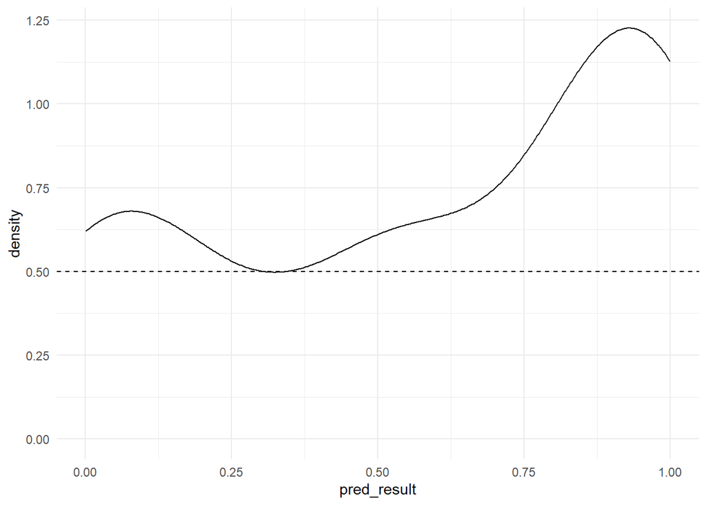

```r
ggplot(heart_test, aes(x=pred_result)) +
  geom_density() +
  geom_hline(yintercept = 0.5 , linetype="dashed") +
  theme_minimal()
```

Based on result predict in logistic regression, value >0.5 (Heart Disease) more than value <0.5 (Not Heart Disease)

#### 4.2 K-Nearest Neighbor

**Check Proportion**

```r
prop.table(table(heart$target))
```

```
##
## Not Heart Disease     Heart Disease
##         0.4554455         0.5445545
```

Proportion data for target variabel (Not Heart Disease 45%) and (Heart Disease 54%) still balance

**Cross Validation**

Cross validation knn variabel predictor for axes x and variabel target for y axis

```r
#Variabel Predictor
model_knn_train_x <- heart_train %>% select(-c(target,sex,cp,fbs,restecg,exang,slope,ca,thal))
model_knn_test_x <- heart_test %>% select(-c(target,sex,cp,fbs,restecg,exang,slope,ca,thal,pred_result,pred_label))

#Variabel Target
model_knn_train_y <- heart_train %>% select(target)
model_knn_test_y <- heart_test %>% select(target)
```

**Scaling**

```r
# scale train_x data
model_knn_train_xs <- scale(model_knn_train_x)

# scale test_x data
model_knn_test_xs <- scale(model_knn_test_x,
      center = attr(model_knn_train_xs, "scaled:center"),
      scale = attr(model_knn_train_xs, "scaled:scale"))
```

**Prediction**

Find Optimum KNN

```r
round(sqrt(nrow(model_knn_train_xs)))
```

```
## [1] 16
```

KNN Predict

```r
heart_knn_pred <- knn(train = model_knn_train_xs,
                 test = model_knn_test_xs,
                 cl = model_knn_train_y$target,
                 k=16)
heart_knn_pred
```

```
##  [1] Not Heart Disease Heart Disease     Heart Disease     Not Heart Disease
##  [5] Heart Disease     Heart Disease     Not Heart Disease Not Heart Disease
##  [9] Heart Disease     Heart Disease     Heart Disease     Not Heart Disease
## [13] Heart Disease     Heart Disease     Heart Disease     Not Heart Disease
## [17] Heart Disease     Heart Disease     Heart Disease     Heart Disease
## [21] Heart Disease     Not Heart Disease Heart Disease     Heart Disease
## [25] Heart Disease     Heart Disease     Heart Disease     Heart Disease
## [29] Heart Disease     Not Heart Disease Heart Disease     Not Heart Disease
## [33] Heart Disease     Not Heart Disease Heart Disease     Heart Disease
## [37] Heart Disease     Heart Disease     Heart Disease     Heart Disease
## [41] Not Heart Disease Heart Disease     Not Heart Disease Heart Disease
## [45] Not Heart Disease Heart Disease     Not Heart Disease Not Heart Disease
## [49] Not Heart Disease Not Heart Disease Not Heart Disease Not Heart Disease
## [53] Not Heart Disease Heart Disease     Not Heart Disease Not Heart Disease
## [57] Not Heart Disease Not Heart Disease Heart Disease     Heart Disease
## [61] Not Heart Disease
## Levels: Not Heart Disease Heart Disease
```

### 5. Evaluation

#### 5.1 Logistic Regression

For evaluation using confusion matrix

```r
model_log_eval <- confusionMatrix(heart_test$pred_label, heart_test$target, positive = "Heart Disease")
model_log_eval
```

```
## Confusion Matrix and Statistics
##
##                    Reference
## Prediction          Not Heart Disease Heart Disease
##   Not Heart Disease                15             6
##   Heart Disease                     6            34
##
##                Accuracy : 0.8033
##                  95% CI : (0.6816, 0.894)
##     No Information Rate : 0.6557
##     P-Value [Acc > NIR] : 0.008813
##
##                   Kappa : 0.5643
##
##  Mcnemar's Test P-Value : 1.000000
##
##             Sensitivity : 0.8500
##             Specificity : 0.7143
##          Pos Pred Value : 0.8500
##          Neg Pred Value : 0.7143
##              Prevalence : 0.6557
##          Detection Rate : 0.5574
##    Detection Prevalence : 0.6557
##       Balanced Accuracy : 0.7821
##
##        'Positive' Class : Heart Disease
##
```

**Summary Evaluation Logistic Regression**

*-Accuracy : 0.8033 –> 80.3% model to correctly guess the target (Heart Disease / Not Heart Disease).*

*-Sensitivity (Recall) : 0.8500 –> 85% from all the positive actual data, capable proportion of model to guess right.*

*-Specificity : 0.7143 –> 71.4% from all the negative actual data, capable proportion of model to guess right.*

*-Pos Pred (Precision) : 0.8500 –> 85% from all the prediction result, capable model to correctly guess the positive class.*

#### 5.2 K-Nearest Neighbor

For evaluation using confusion matrix

```r
conf_knn <- confusionMatrix(data=heart_knn_pred,
                            reference = as.factor(model_knn_test_y$target),
                            positive="Heart Disease")
conf_knn
```

```
## Confusion Matrix and Statistics
##
##                    Reference
## Prediction          Not Heart Disease Heart Disease
##   Not Heart Disease                15            10
##   Heart Disease                     6            30
##
##                Accuracy : 0.7377
##                  95% CI : (0.6093, 0.842)
##     No Information Rate : 0.6557
##     P-Value [Acc > NIR] : 0.1111
##
##                   Kappa : 0.4442
##
##  Mcnemar's Test P-Value : 0.4533
##
##             Sensitivity : 0.7500
##             Specificity : 0.7143
##          Pos Pred Value : 0.8333
##          Neg Pred Value : 0.6000
##              Prevalence : 0.6557
##          Detection Rate : 0.4918
##    Detection Prevalence : 0.5902
##       Balanced Accuracy : 0.7321
##
##        'Positive' Class : Heart Disease
##
```

**Summary Evaluation K-Nearest Neighbor**

*-Accuracy : 0.7377 –> 73.7% model to correctly guess the target (Heart Disease / Not Heart Disease).*

*-Sensitivity (Recall) : 0.7500 –> 75% from all the positive actual data, capable proportion of model to guess right.*

*-Specificity : 0.7143 –> 71.4% from all the negative actual data, capable proportion of model to guess right.*

*-Pos Pred (Precision) : 0.8333 –> 83.3% from all the prediction result, capable model to correctly guess the positive class.*

### 6. Summary

```r
model <- c("Logistic Regression", "K-Nearest Neighbor")
Accuracy <- c(0.8033,0.7377)
Sensitivity_Recall <- c(0.8500,0.7500)
Specificity <- c(0.7143,0.7143)
Pos.Pred_Precision <- c(0.8500,0.8333)

tabelmodel <- data.frame(model,Accuracy,Sensitivity_Recall,Specificity,Pos.Pred_Precision)

print(tabelmodel)
```

```
##                 model Accuracy Sensitivity_Recall Specificity
## 1 Logistic Regression   0.8033               0.85      0.7143
## 2  K-Nearest Neighbor   0.7377               0.75      0.7143
##   Pos.Pred_Precision
## 1             0.8500
## 2             0.8333
```

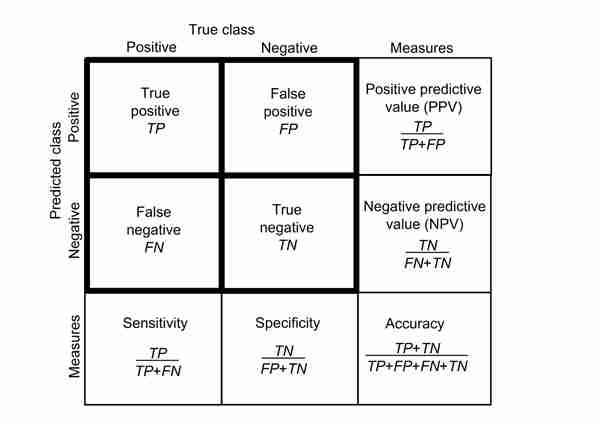

**Based on the results of each model, both of model have a good results in term of Accuracy, Recall, Specificity and Precision.**

**From business case, I want to choose patients with Heart Disease, for that I choose a model with high value Post Pred (Precision) and Accuracy. I choose a model with a high value Post Pred (Precision) and Accuracy because I want the model be able to predict accurately and don’t want wrong prediction of patients with Heart Disease or FP (Prediction correct but Actual wrong) is better than FN (Prediction wrong but Actual correct).**